# COVID19 Mini-Project

# Research Questions

I would like to investigate the trends in daily new COVID-19 cases and their relationship with daily new deaths over time in Australia.

# Data set introduction

This dataset contains COVID-19 daily statistics for Australia up to the end of 2022. It records daily and cumulative counts of new cases and deaths.

The dataset includes:

date: Date of the data entry.  
new_cases and new_deaths: Counts of new COVID-19 cases and deaths reported daily.  
total_cases and total_deaths: Total cumulative counts of cases and deaths up to the given date.

```r
# Load the data
data <- read.csv("Data/Australia_Data_till_End_of_2022.csv")


# Create a table of variable names
variable_names <- data.frame(Variable_Names = colnames(data))
kable(variable_names, col.names = "Variable Names")
```

| Variable Names |
| --- |
| date |
| new_cases |
| new_deaths |
| total_cases |
| total_deaths |

# Data set description

```
## 'data.frame':    2 obs. of  5 variables:
##  $ date        : chr  "1/05/2020" "1/06/2020"
##  $ new_cases   : int  0 0
##  $ new_deaths  : int  0 0
##  $ total_cases : int  0 0
##  $ total_deaths: int  0 0
```

# Data Summary

## Summary by year

This table shows the mean number of new cases and the total number of new deaths for each year from 2020 to 2022.

```r
# Convert the 'date' column to Date type
data$date <- as.Date(data$date, format = "%d/%m/%Y")  # Adjust the format if necessary
# Create a new column for the year
data$year <- year(data$date)

# Summarize the data by the 'year' column
summary_table <- data %>%
  group_by(year) %>%
  summarise(
    Mean_New_Cases = mean(new_cases, na.rm = TRUE),
    Total_New_Deaths = sum(new_deaths, na.rm = TRUE)
  ) %>%
  head(10)  # Display only the first 10 rows

# Display the summary table with a caption
kable(
  summary_table,
  caption = "Summary of Mean New Cases and Total New Deaths by Year"

)
```

Summary of Mean New Cases and Total New Deaths by Year

| year | Mean_New_Cases | Total_New_Deaths |
| --- | --- | --- |
| 2020 | 78.16575 | 920 |
| 2021 | 926.87945 | 1457 |
| 2022 | 28294.33973 | 15439 |

## Summary by Year-Month:

```r
# Create a new column for the year-month (formatted as "YYYY-MM")
data$year_month <- format(data$date, "%Y-%m")

# Summarize the data by the 'year_month' column
summary_table <- data %>%
  group_by(year_month) %>%
  summarise(
    Mean_New_Cases = mean(new_cases, na.rm = TRUE),
    Total_New_Deaths = sum(new_deaths, na.rm = TRUE)
  ) %>%
  head(10)  # Display only the first 10 rows

# Display the summary table with a caption
kable(
  summary_table,
  caption = "Summary of Mean New Cases and Total New Deaths by Month of Each Year"
)
```

Summary of Mean New Cases and Total New Deaths by Month of Each Year

| year_month | Mean_New_Cases | Total_New_Deaths |
| --- | --- | --- |
| 2020-01 | 3.266667 | 0 |
| 2020-02 | 119.535714 | 95 |
| 2020-03 | 127.300000 | 26 |
| 2020-04 | 17.896552 | 43 |
| 2020-05 | 90.419355 | 27 |
| 2020-06 | 37.233333 | 60 |
| 2020-07 | 144.096774 | 61 |
| 2020-08 | 159.870968 | 353 |
| 2020-09 | 140.933333 | 211 |
| 2020-10 | 12.935484 | 5 |

Both tables help track the progression of COVID-19’s impact over time, reflecting changes in cases and deaths by year and by month.

# Visualisations

## Scatter plot with trend line for new cases

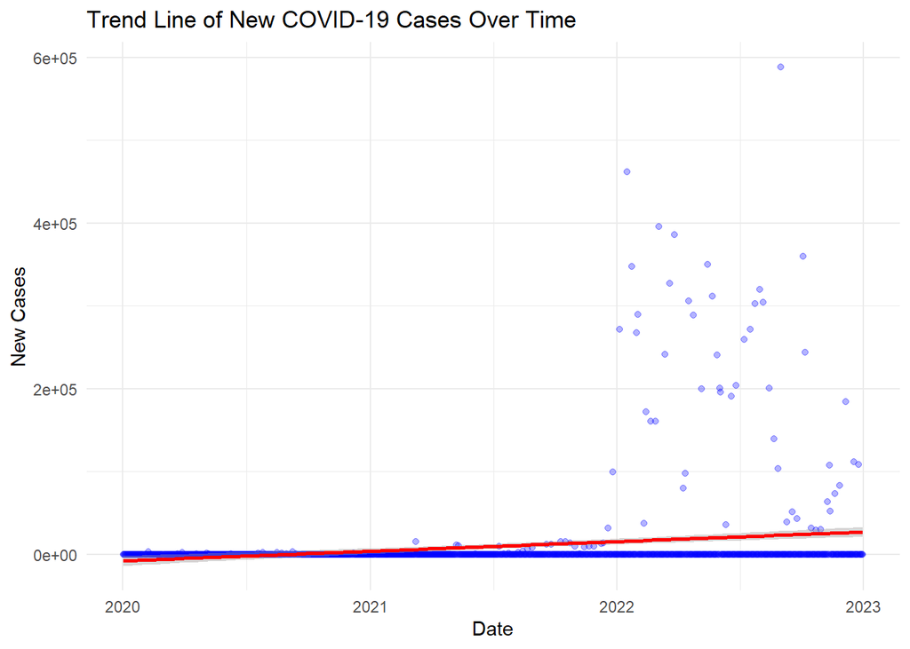

```r
ggplot(data, aes(x = date, y = new_cases)) +
  geom_point(color = "blue", alpha = 0.3) +
  geom_smooth(method = "lm", color = "red") +
  labs(
    title = "Trend Line of New COVID-19 Cases Over Time",
    x = "Date",
    y = "New Cases"
  ) +
  theme_minimal()
```

## Scatter plot with trend line for new deaths

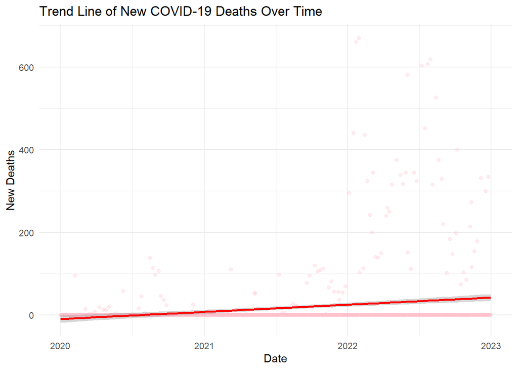

```r
ggplot(data, aes(x = date, y = new_deaths)) +
  geom_point(color = "pink", alpha = 0.3) +
  geom_smooth(method = "lm", color = "red") +
  labs(
    title = "Trend Line of New COVID-19 Deaths Over Time",
    x = "Date",
    y = "New Deaths"
  ) +
  theme_minimal()
```

### Analysis:

I have plotted the trend lines for both new COVID-19 cases and new deaths over time. The red line in each scatter plot represents the trend, showing the overall direction and rate of change over the observed period. These trend lines help highlight any consistent increases or decreases in cases and deaths, making it easier to analyze long-term patterns.

# Conclusion

The analysis of COVID-19 data for Australia highlights distinct trends, especially in 2022, which saw significantly higher averages in new cases and related deaths. This surge was primarily driven by highly transmissible variants like Omicron, easing of public health restrictions, waning vaccine immunity, and increased social interactions. Visualizations, such as scatter plots, confirmed these patterns, showing clear peaks over time that aligned with known waves of heightened transmission. These findings underscore the importance of monitoring variant behavior, maintaining vaccination efficacy through boosters, and understanding public behavior shifts. Insights from this analysis are crucial for crafting targeted public health strategies to manage future outbreaks and minimize severe outcomes.

# References

https://github.com/owid/covid-19-data/tree/master/public/data/vaccinations https://ourworldindata.org/coronavirus